# General Linear Model (3)

## Confounding

General interpretation of model coefficients:  
Effect of the corresponding \(x\) on \(y\), **given all other predictors**

- Coefficients will generally change if we change the model  
  (i.e., eliminate, or add, predictors)
- This provides a way to assess **confounding**:
  - Model 1: \(\quad y = \beta_0 + \beta_1 x_1 + \epsilon\)
  - Model 2: \(\quad y = \beta_0 + \beta_1 x_1 + \beta_2 x_2 + \epsilon\)

\(x_2\) is a **counfounder** for \(x_1\), if the effect of \(x_1\) (that is, \(\beta_1\)) is different in Model 1 and Model 2

## Confounding example (simulated data)

- Suppose an observational study comparing lipid lowering drugs A and B
- Colesterol is measured pre- and pos-treament

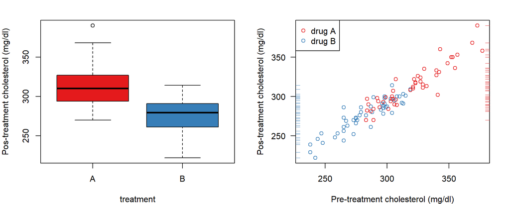

## Modelling pos-treatment values (y)

- A first model (m1) including only **treatment** as predictor (A is the reference level)
- A second model (m2) including both **treatment** and **pre-treatment values (x)**
- In both models, \(\beta_{treatmentB}\) is the expected **difference** betwen B and A (the **reference** level)

```r
m1 = lm(y ~ treatment); print(summary(m1)$coeff,digits=2)
```

```
            Estimate Std. Error t value Pr(>|t|)
(Intercept)      313        3.5    90.6  1.5e-95
treatmentB       -37        4.9    -7.6  1.7e-11
```

```r
m2 = lm(y ~ x + treatment); print(summary(m2)$coeff,digits=2)
```

```
            Estimate Std. Error t value Pr(>|t|)
(Intercept)    16.58     13.589     1.2  2.3e-01
x               0.93      0.042    21.9  3.6e-39
treatmentB     -3.10      2.523    -1.2  2.2e-01
```

- Note that treatment effect is no longer significant
- Note how small is now the estimated treatment effect

## The two models, grapically

In both plots, the treatment effect is the *vertical* distance between lines (A-B):

\(\qquad \qquad\) **m1**: quite obviously, -37 mg/dl \(\qquad \qquad \qquad\) **m2**: *given* \(x\), -3 mg/dl

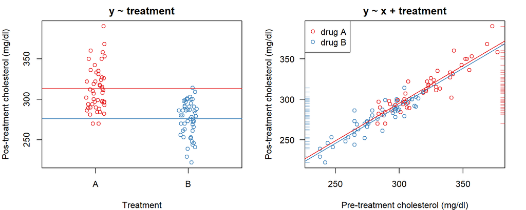

## Interaction

Interaction between two predictors \(x_1\) and \(x_2\):

- the effect of \(x_1\) is not constant, but depends on \(x_2\)
- the effect of \(x_2\) is not constant, but depends on \(x_1\)

If this is the case, we say that

- \(x_2\) is an effect modifier for \(x_1\)
- \(x_1\) is an effect modifier for \(x_2\)

## Interaction example

- Clinical trial on a lipid lowering drug vs placebo; blood colesterol is measured pre- and pos-treatment
- Note in this case pre-treatment values are similar in both treatment groups

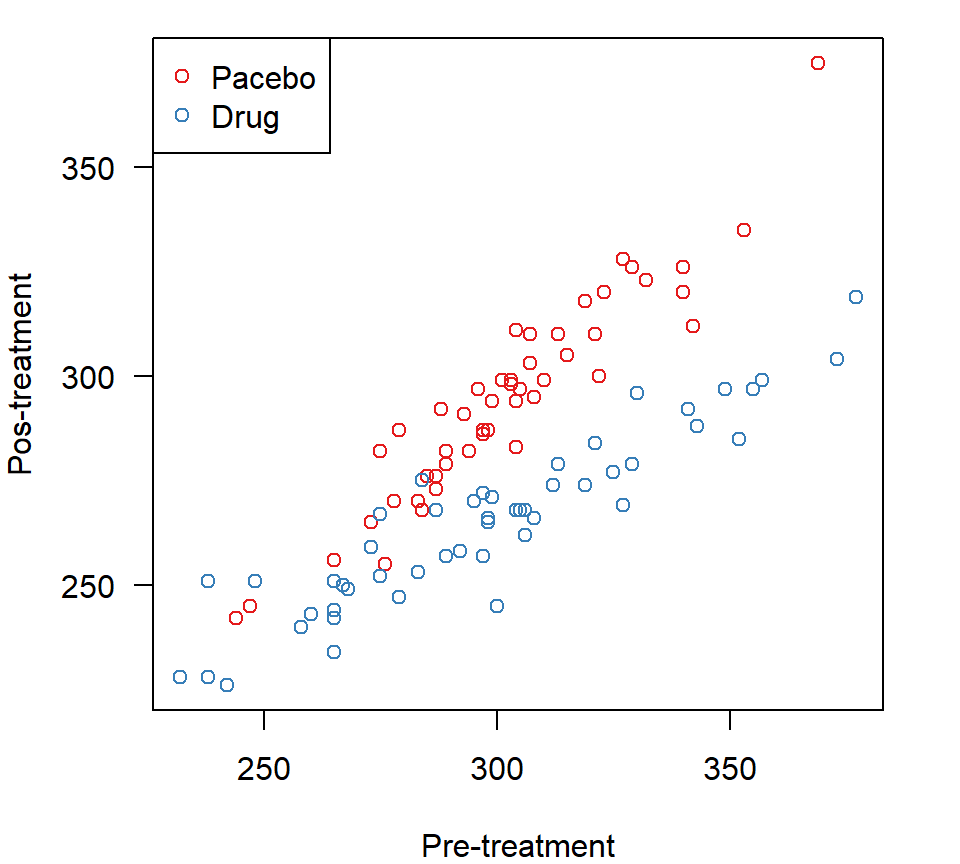

## Fitting models with/without interaction

```r
m1 = lm(y ~ x + t); summary(m1)$coeff                  # without interaction
```

```
               Estimate Std. Error    t value     Pr(>|t|)
(Intercept)  92.1311564 9.89595910   9.309977 4.146247e-15
x             0.6702884 0.03239207  20.692981 2.363127e-37
t           -26.3826155 1.97090071 -13.386070 9.101669e-24
```

```r
m2 = lm(y ~ x + t + x:t); summary(m2)$coeff            # with interaction
```

```
              Estimate  Std. Error    t value     Pr(>|t|)
(Intercept)  9.2364567 14.05553143  0.6571403 5.126631e-01
x            0.9443386  0.04631821 20.3880627 1.178016e-36
t           95.1555239 16.99646000  5.5985496 2.048864e-07
x:t         -0.4038656  0.05622832 -7.1825998 1.459984e-10
```

## The two models, grapically

In both cases we fit two lines (one for each treatment), but:

\(\qquad\) different intercept, same slope \(\qquad\) different intercept, different slope

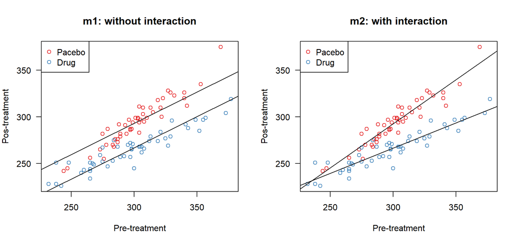

## Exercise

A simple experiment on [pulse rate before and after physical exercise](http://www.statsci.org/data/oz/ms212.html)

```r
d <- rio::import("http://www.statsci.org/data/oz/ms212.txt")
```

`Pulse1`: pulse rate before intervention.

`Ran`: randomized intervention, either 1=Ran, or 2=Sat, for 1 minute.

`Pulse2`: pulse rate after intervention

## Exercise (cont)

- Are there any missing values in `d`? If yes, subset `d` to eliminate them.
- Create factor `group`, with levels “Sat” and “Ran” (in this order)
- Fit a linear model for `Pulse2` with `group` as predictor. From the model summary:
  - Did running have an effect on the pulse rate?
  - By how much the pulse is affected by running? provide a 95 CI.
  - What is the predicted value of `Pulse2` for:
    - students that sat?
    - those who ran?
  - Verify by computing the means of `Pulse2` in both groups.

## Exercise (cont)

- Fit a second model with both `group` and `Pulse1` as predictors, and:
  - Test for a possible interaction. If not significant, remove interaction term from the model.
  - What is now the estimated effect of running on the pulse rate? provide 95% CI.